# Understanding Ethereum Verification Bottlenecks

```python
# INIT

import matplotlib.pyplot as plt
import squarify    # pip install squarify (algorithm for treemap)
import pandas as pd
import numpy as np
import seaborn as sns

plt.rcParams['font.size'] = 14
plt.rcParams["figure.figsize"] = (14,10)
```

https://www.renlord.com/research/cp3/understanding-ethereum-verification-bottlenecks.html

For the purposes of analysing client-side transaction verification bottlenecks, we elected to analyse `go-ethereum`, `openethereum` and `turbo-geth`. We picked `go-ethereum` and `openethereum` as they are both common clients used in the network as shown in [1]. 80% of nodes use `geth`, 14% of nodes use `openethereum`. Our analysis captures approx. 95% of the network.

[1] https://www.ethernodes.org/

We include `turbo-geth` as part of our analysis as it is a unique implementation that represents and processes state in a different way compared to `go-ethereum` and `openethereum`.

We attempt to quantify the cost of maintaining an online authenticated state database through this work and present our findings on what are the bottlenecks during transaction verification and node bootstrapping.

### Overview --- how long it takes for our target clients to full-sync?

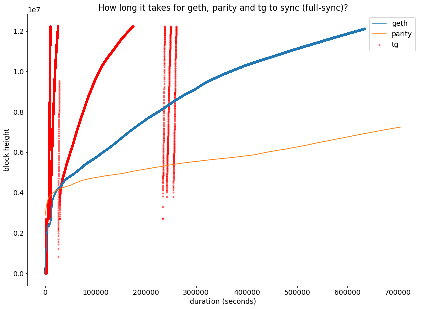

```python
geth = pd.read_csv('/scratch/renlord/cp3-data/geth-data/geth-sec-blocknum.dat', delimiter='-', names=['time', 'blocknum'])
parity = pd.read_csv('eth-data/parity-sec-blocknum.dat', delimiter='-', names=['time', 'blocknum'])
tg = pd.read_csv('/scratch/renlord/cp3-data/tg-data/tg-sec-blocknum.dat', delimiter='-', names=['time', 'blocknum'])

geth_line, = plt.plot(geth['time'], geth['blocknum'], label='geth')
pari_line, = plt.plot(parity['time'], parity['blocknum'], label='parity')
tg_line = plt.scatter(tg['time'], tg['blocknum'], label='tg', marker='.', color='red', alpha=0.5)
plt.xlabel('duration (seconds)')
plt.ylabel('block height')
plt.title('How long it takes for geth, parity and tg to sync (full-sync)?')
plt.legend()
plt.show()
```

This line plot shows the time taken for the different SUTs to synchronise the ethereum blockchain under similar configurations settings on the same hardware machine.

`tg` scatter oscilliates between 0 and 1.2e7 due to how `tg` does full sync. It performs full-sync in stages. It initially downloads all block headers and bodies at the first two stages, then follows with executing all transactions recorded in block bodies in the 5th stage, which is shown as a the longest stage. In the 5th stage, we observe that as the number of processed transaction increases, the rate of transaction processed slows towards the end of the execution stage. In constrast to the other two client implementation, the slow-down in transaction execution starts significantly earlier.

## `Go-Ethereum` Runtime Observations

What we have collected to date:

1. On-CPU runtime profiling for openethereum, geth and turbo-geth
2. Off-CPU runtime profiling for geth ONLY.
3. State Access Patterns up to Block 7M+ --- produced interblock height and state touch counts.
4. Collected client logs that show timestamps, block count, gas consumption

What can we infer from the data:

1. For On-CPU runtime profiling flamegraphs, since we have the full stack trace when samples are collected, we can infer how often there's a cache hit/miss.
2. Proportion of time spent on various operations.

### What is the execution runtime profile?

[figure not shown]

**Merged Samples across entire chain length**

#### Analysis

From the treemap below, we see that most of the time is spent in transaction execution, followed by appending verified blocks to the local copy of the blockchain, followed closely by the Go Runtime.

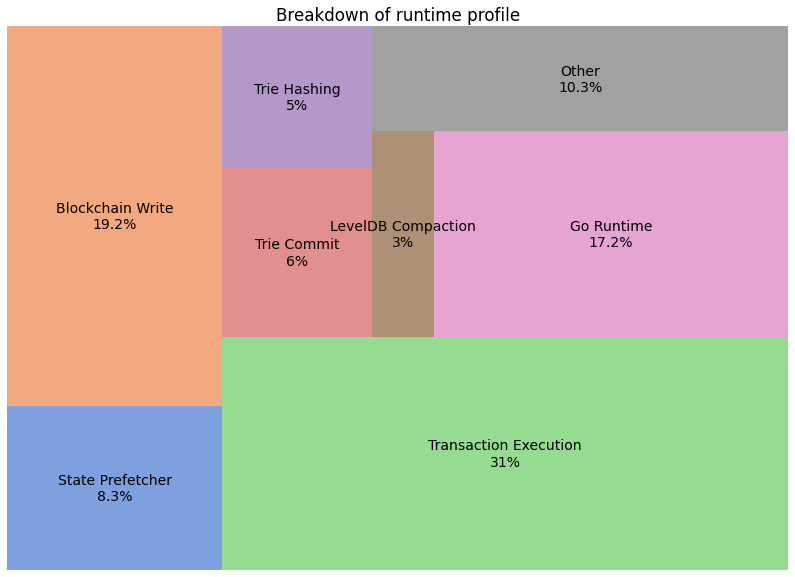

```python
data = [
    ("State Prefetcher", 8.3),
    ("Blockchain Write", 19.2),
    ("Transaction Execution", 31),
    ("Trie Commit", 6),
    ("Trie Hashing", 5),
    ("LevelDB Compaction", 3),
    ("Go Runtime", 17.2),
    ("Other", 10.3)
]

clrs = sns.color_palette('muted', n_colors=len(data))

dfa = ["\n".join([d1, str(d2) + "%"]) for (d1, d2) in data]
dfb = [d2 for (_, d2) in data]

df = pd.DataFrame({'Usage': dfb, 'Category': dfa})

squarify.plot(sizes=df['Usage'], label=df['Category'], alpha=.7, color=clrs)
plt.axis('off')
plt.title("Breakdown of runtime profile")
plt.show()
```

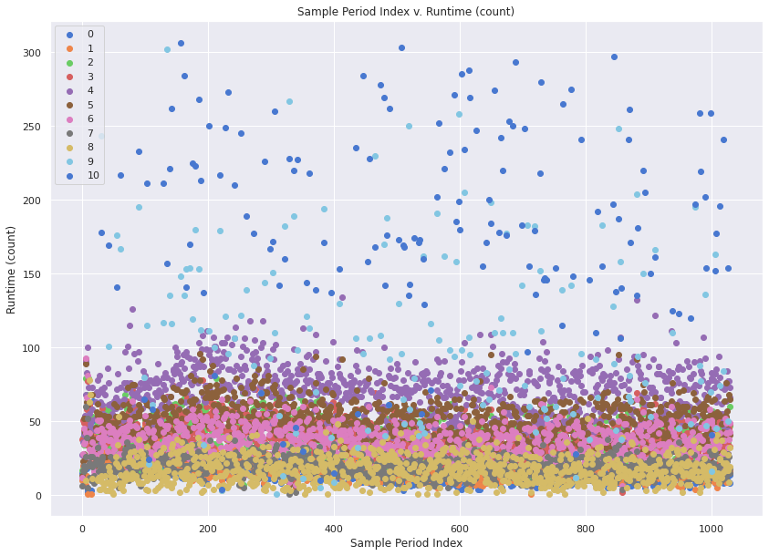

```python
data = open('/scratch/renlord/cp3-data/geth-data/runtime.append', 'r')
import ast
data_list = []
keys = []
# prune outliers where offcpu time exceeds 100ms.
def prune_outlier(points):
    return [(x, y) for (x, y) in points if y < 100000]

def cum_count(_data):
    cum = 0
    for (idx, count) in _data:
        cum += count
    return cum

for line in data:
    key = line.split(' ')[0]
    _data = ''.join(line.split(' ')[1:]).strip('\n')
    _data = ast.literal_eval(_data)
    # drop stack if less than 20000 samples collected across 1000+ sampling periods.
    if cum_count(_data) > 15000:
        #_data = prune_outlier(_data)
        data_list.append(_data)
        keys.append(key)

clrs = sns.color_palette('muted', n_colors=len(keys))
# transform stack trace data to (x,y) scatterplot compatible format.
for i in range(0,len(keys)):
    x = [xx for xx, _ in data_list[i]]
    y = [yy for _, yy in data_list[i]]
    plt.scatter(x, y, c=np.array(clrs[i]).reshape(1,-1), label=i)
legend = list(range(0, len(keys)))
plt.title("Sample Period Index v. Runtime (count)")
plt.xlabel("Sample Period Index")
plt.ylabel("Runtime (count)")
plt.legend()
plt.show()
```

```python
for i in range(len(keys)):
    print(i, keys[i])
```

```
0 G/trie.(*Trie).Commit.func1;G/trie.(*committer).commitLoop;G/trie.(*Database).insert;G/trie.(*cachedNode).forChilds;G/trie.forGatherChildren;G/trie.forGatherChildren;G/trie.(*Database).insert.func1
1 G/trie.(*Trie).Commit.func1;G/trie.(*committer).commitLoop;G/trie.(*Database).insert;G/trie.(*cachedNode).forChilds;G/trie.forGatherChildren;G/trie.forGatherChildren;G/trie.(*Database).insert.func1;runtime.mapaccess1
2 runtime.bgsweep;runtime.sweepone
3 runtime.gcBgMarkWorker;runtime.systemstack;runtime.gcBgMarkWorker.func2;runtime.gcDrain
4 runtime.gcBgMarkWorker;runtime.systemstack;runtime.gcBgMarkWorker.func2;runtime.gcDrain;runtime.scanobject
5 runtime.gcBgMarkWorker;runtime.systemstack;runtime.gcBgMarkWorker.func2;runtime.gcDrain;runtime.scanobject;runtime.findObject
6 runtime.gcBgMarkWorker;runtime.systemstack;runtime.gcBgMarkWorker.func2;runtime.gcDrain;runtime.scanobject;runtime.markBits.isMarked
7 runtime.gcBgMarkWorker;runtime.systemstack;runtime.gcBgMarkWorker.func2;runtime.gcDrain;runtime.scanobject;runtime.pageIndexOf
8 G/eth/downloader.(*Downloader).spawnSync.func1;G/eth/downloader.(*Downloader).processFullSyncContent;G/eth/downloader.(*Downloader).importBlockResults;G/core.(*BlockChain).InsertChain;G/core.(*BlockChain).insertChain;G/core.(*BlockChain).writeBlockWithState;G/trie.(*Database).Cap;G/ethdb/leveldb.(…
9 github.com/syndtr/goleveldb/leveldb.(*DB).tCompaction;github.com/syndtr/goleveldb/leveldb.(*DB).tableAutoCompaction;github.com/syndtr/goleveldb/leveldb.(*DB).tableCompaction;github.com/syndtr/goleveldb/leveldb.(*DB).compactionTransact;github.com/syndtr/goleveldb/leveldb.(*tableCompactionBuilder).r…
10 github.com/syndtr/goleveldb/leveldb.(*DB).tCompaction;github.com/syndtr/goleveldb/leveldb.(*DB).tableAutoCompaction;github.com/syndtr/goleveldb/leveldb.(*DB).tableCompaction;github.com/syndtr/goleveldb/leveldb.(*DB).compactionTransact;github.com/syndtr/goleveldb/leveldb.(*tableCompactionBuilder).…
```

### Off-CPU Traces (geth)

From the off-cpu traces, it is clear that db operations, specifically goleveldb ones frequently put the process into uninterruptible sleep while the kernel retrieves data from disk over VFS syscalls. DB compaction operations take more time than DB read operations when it comes to off-cpu blocking time. Specifically for off-cpu DB trie node reads, the reads from disc are specific to nodes that are deep in the Ethereum state trie which suggest that frequently visited nodes at lo wer depth along the trie enjoy high cache hit rates.

[figure not shown]

The way off-cpu is measured involves tracing when the target process is prempted by the scheduler and placed in `uninterruptible sleep` state. We specifically target off-cpu traces when in this state as processes are put in this state iff the process must yield the CPU due to waiting on an I/O operation.

Bar width indicates proportion of time spent off-time.

Bar height represents the function stack at the time when process is placed in `uninterruptible sleep`.

**IF YOU WANT TO LOOK AT THESE INTERACTIVELY and be able to click on them, go to:**

- https://www.renlord.com/research/cp3/geth-merged.svg
- https://www.renlord.com/research/cp3/geth.cpuofftime.svg
- https://www.renlord.com/research/cp3/geth2.cpuofftime.svg
- https://www.renlord.com/research/cp3/geth-offcpu-3.svg (colour difference not significant)

## `OpenEthereum (rust)` Runtime Observations

`openethereum` or `oe` for short implements its initial sync in either `warp-sync` mode or `full-sync` mode. We elected to run `oe` in `full-sync` mode for a direct comparison against `geth` and `tg`.

```python
# --callgraph lbr forgotten.
```

## `TurboGeth (golang)` Runtime Observations

`turbo-geth` implements its initial sync in a different method to the other two clients.

1. Download headers and check PoW of headers.
2. Create an index of blockhashes.
3. Download block bodies
4. Recover and stores senders for each transaction.
5. Execute blocks in serial. Does not build merkle trie and does not check root hashes against merkle root hash in blockchain.
6. Generate Hashed State (to maintain API compatbility with other clients).
7. Compute State Root and Intermediate Hashes.
8. Generate Indexes for Stages 8, 9, 10, 11.

Finish.

#### Overall Runtime Profile

[figure not shown]

https://www.renlord.com/research/cp3/tg-merged.svg

#### Breakdown of runtime by Sync Stages

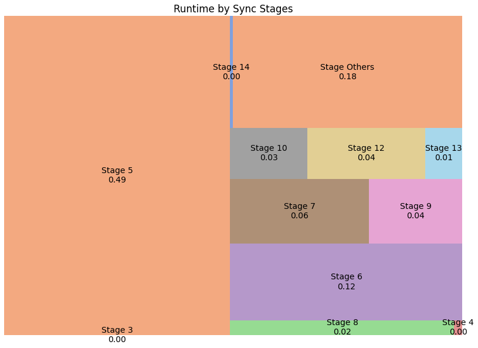

```python
data = open('/scratch/renlord/cp3-data/tg-data/merged.collapse', 'r')
import re

stages = dict()
stotal = 0
sync = 0

for line in data:
    m = re.search(r'DefaultStages\.func(\d+)', line)
    s = int(line.split(' ')[1])
    if m is not None:
        stage = m.group(1)
        if stage in stages:
            stages[stage] += s
        else:
            stages[stage] = s
        sync += s
    stotal += s

if stotal != sync:
    stages['Others'] = stotal - sync

clrs = sns.color_palette('muted', n_colors=len(stages))

dfa = ["\n".join(["Stage " + str(k), "{:.2f}".format(v/stotal)]) for k,v in stages.items()]
dfb = [v for _, v in stages.items()]

df = pd.DataFrame({'Count': dfb, 'Stage': dfa})

squarify.plot(sizes=df['Count'], label=df['Stage'], alpha=.7, color=clrs)
plt.axis('off')
plt.title("Runtime by Sync Stages")
plt.show()
```

#### Analysis

Unsurprisingly most of the client workload consists of Stage 5 which involves replaying all transaction executions. The next highest workload stage is 6 which involves generating hashed states to rebuild consensus-compatible data structure, state trie, followed by Stage 7.

#### Offcpu Analysis

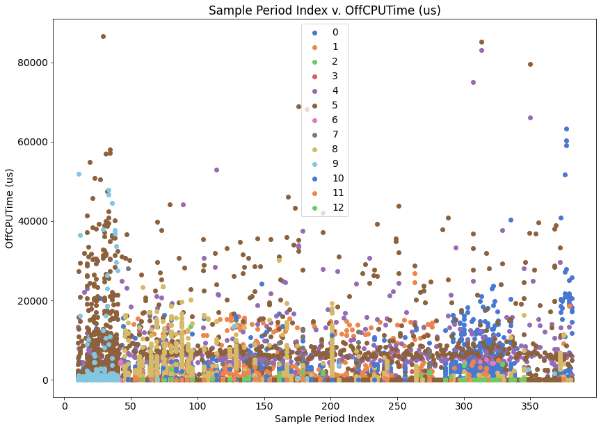

```python
data = open('/scratch/renlord/CP3-RAW/tg-geth/processed-data/append.collapse', 'r')

import ast

data_list = []
keys = []

# prune outliers where offcpu time exceeds 100ms.
def prune_outlier(points):
    return [(x, y) for (x, y) in points if y < 100000]

for line in data:
    key = line.split(' ')[0]
    _data = ''.join(line.split(' ')[1:]).strip('\n')
    _data = ast.literal_eval(_data)

    # drop stack if less than 100 samples collected across 382 sampling periods.
    if len(_data) > 100:
        _data = prune_outlier(_data)
        data_list.append(_data)
        keys.append(key)

clrs = sns.color_palette('muted', n_colors=len(keys))

# transform stack trace data to (x,y) scatterplot compatible format.
for i in range(0,len(keys)):
    x = [xx for xx, _ in data_list[i]]
    y = [yy for _, yy in data_list[i]]
    plt.scatter(x, y, c=np.array(clrs[i]).reshape(1,-1), label=i)

legend = list(range(0, len(keys)))

plt.title("Sample Period Index v. OffCPUTime (us)")
plt.xlabel("Sample Period Index")
plt.ylabel("OffCPUTime (us)")
plt.legend()
plt.show()
```

```python
# stack trace index
for i in range(0,len(keys)):
    print(i, keys[i])
```

```
0 tg;runtime.goexit;runtime.systemstack;runtime.bgscavenge.func2;runtime.(*pageAlloc).scavenge;runtime.(*pageAlloc).scavengeOne;runtime.(*pageAlloc).scavengeRangeLocked;runtime.madvise;-;entry_SYSCALL_64_after_hwframe;do_syscall_64;SyS_madvise;SYSC_madvise;down_write_killable;call_rwsem_down_write_f…
1 tg;runtime.goexit;runtime.systemstack;runtime.gcBgMarkWorker.func2;runtime.gcDrain;runtime.scanobject;-;page_fault;do_page_fault;__do_page_fault;handle_mm_fault;__handle_mm_fault;do_swap_page;migration_entry_wait;__migration_entry_wait;wait_on_page_bit;io_schedule;schedule;finish_task_switch
2 tg;runtime.goexit;runtime.systemstack;runtime.gcBgMarkWorker.func2;runtime.gcDrain;runtime.scanobject;runtime.findObject;-;page_fault;do_page_fault;__do_page_fault;handle_mm_fault;__handle_mm_fault;do_swap_page;migration_entry_wait;__migration_entry_wait;wait_on_page_bit;io_schedule;schedule;finis…
3 tg;[unknown];__writev;-;entry_SYSCALL_64_after_hwframe;do_syscall_64;sys_writev;do_writev;vfs_writev;do_iter_write;do_iter_readv_writev;ext4_file_write_iter;__generic_file_write_iter;generic_perform_write;ext4_da_write_begin;__ext4_journal_start_sb;jbd2__journal_start;start_this_handle;add_transac…
4 tg;__GI___pwrite64;-;entry_SYSCALL_64_after_hwframe;do_syscall_64;sys_pwrite64;vfs_write;__vfs_write;new_sync_write;ext4_file_write_iter;vfs_fsync_range;ext4_sync_file;file_write_and_wait_range;__filemap_fdatawait_range;wait_on_page_bit_common;io_schedule;schedule;finish_task_switch
5 tg;[unknown];fdatasync;-;entry_SYSCALL_64_after_hwframe;do_syscall_64;sys_fdatasync;do_fsync;vfs_fsync_range;ext4_sync_file;file_write_and_wait_range;__filemap_fdatawait_range;wait_on_page_bit_common;io_schedule;schedule;finish_task_switch
6 tg;[MissedUserStack];page_fault;do_page_fault;__do_page_fault;down_read;call_rwsem_down_read_failed;rwsem_down_read_failed;schedule;finish_task_switch
7 tg;runtime.goexit;runtime.systemstack;runtime.gcBgMarkWorker.func2;runtime.gcDrain;runtime.scanobject;runtime.findObject;-;page_fault;do_page_fault;__do_page_fault;down_read;call_rwsem_down_read_failed;rwsem_down_read_failed;schedule;finish_task_switch
8 tg;runtime.goexit;runtime.systemstack;runtime.gcBgMarkWorker.func2;runtime.gcDrain;runtime.scanobject;-;page_fault;do_page_fault;__do_page_fault;down_read;call_rwsem_down_read_failed;rwsem_down_read_failed;schedule;finish_task_switch
9 tg;[unknown];fdatasync;-;entry_SYSCALL_64_after_hwframe;do_syscall_64;sys_fdatasync;do_fsync;vfs_fsync_range;ext4_sync_file;jbd2_complete_transaction;jbd2_log_wait_commit;schedule;finish_task_switch
10 tg;runtime.goexit;runtime.systemstack;runtime.gcBgMarkWorker.func2;runtime.gcDrain;runtime.(*gcWork).balance;runtime.handoff;runtime.getempty;-;page_fault;do_page_fault;__do_page_fault;down_read;call_rwsem_down_read_failed;rwsem_down_read_failed;schedule;finish_task_switch
11 tg;runtime.futex;-;page_fault;do_page_fault;__do_page_fault;down_read;call_rwsem_down_read_failed;rwsem_down_read_failed;schedule;finish_task_switch
12 tg;runtime.goexit;runtime.systemstack;runtime.gcBgMarkWorker.func2;runtime.gcDrain;runtime.scanobject;runtime.greyobject;-;page_fault;do_page_fault;__do_page_fault;down_read;call_rwsem_down_read_failed;rwsem_down_read_failed;schedule;finish_task_switch
```

### Analysis

We collected data across 382 distinct sampling periods, which ran in 15-minutely intervals. The duration of each sample period is 10 seconds and the sampling rate was set at 100Hz. Noise-induced outliers were removed, the number of these outliers were negligible, only a handful.

There is no observed correlation between sample period and the amount of offcputime.

The offcpu profiles do follow closely with the stage the client software is in (i.e. between 0 ~ 45, the client software downloads block headers, bodies content to store on disk and we can see that significant amount of offcpu time is spent on this stage on fsync waits).

`sys_fdatasync` operations offcpu are mostly consistent in its offcpu time, taking approx. less than 10ms, with some outlier samples above the 20ms mark. This is likely due to vfs syscall contention with other processes since the process was run while other experiments were run in the background.

We dropped 1000+ other stack samples as the amount of samples collected were negligible and do not appear consistently across the entire experiment sampling period.

## State Data Introspection

We now investigate the state access pattern for `geth` and `oe`.

```python
# Access Profile in Ethereum
import datashader as ds
import pandas as pd
import holoviews as hv

from holoviews import opts

from holoviews.operation.datashader import datashade, shade, dynspread, rasterize
from holoviews.operation import decimate, histogram

hv.extension('bokeh','matplotlib')
```

```python
# data processing for Stage 1 of ETH data collection
import os

RAW_DAT_DIR="/scratch/renlord/ethresearch-iterator"
if not os.path.isfile(f"{RAW_DAT_DIR}/blockheights-data"):
    print("Need to run ethresearch-iterator on muppet first!")

DATA_DIR="/scratch/renlord/cp6/eth-data"
if not os.path.isfile(f"{DATA_DIR}/accid-height"):
    fd = open(f"{RAW_DAT_DIR}/blockheights-data", 'r')
    with open(f"{DATA_DIR}/accid-height", 'w+') as out:
        line = fd.readline()
        acc_count = 0
        while line:
            blocks = line.split(' ')[1].strip('\n')
            blocks = blocks.split(',')
            for b in blocks:
                out.write(f'{acc_count},{int(b)}\n')
            acc_count +=1
            line = fd.readline()
    fd.close()
```

```python
data = pd.read_csv(f'{DATA_DIR}/accid-height', names=['state', 'blockheight'])
```

Y-axis represent unique state objects. X-axis represent block height. Each point represents an instance of accessing a state object at a specific blockheight. The brightness of a point is the relative "business" of its accesses compared to other adjacent state objects ordered in numerical ascending order of state object hash IDs.

**NOTE: DoS height intervals 2.3 ~ 2.7M blockheight, to ignore in analysis (Mispriced EXTCODESIZE)**

```python
data2 = data[data['blockheight'] > 2786000 ]
```

```python
points = hv.Points(data2, ['blockheight', 'state'], label="access profile")
rasterize(points).opts(width=1000, height=600)
```

[interactive chart not shown]

Ethereum state data is parsely scattered which results in poor spatial locality.

This heatmap excludes mispriced EXTCODESIZE blocks and starts at 2.7M+ blockheight.

Yellow shades indicate high touch frequency, while dark shades indicate low touch frequency.

Inferring from heatmap, access patterns are randomly scattered across accounts where some accounts are frequently touched as shown by bright horizontal red/yellow shades.

### Colleration Analysis of State Access Patterns

```python
import json, statistics
import matplotlib as mpl
from matplotlib import pyplot

TRACE_RESULTS_DIR='/scratch/renlord/cp6/go-pprof-results/'
funcs = {}

data = []
with open(f'{TRACE_RESULTS_DIR+"functime.out"}', 'r') as f:
    for line in f:
        if 'percent' in line:
            percents = json.loads(line.split(":")[1].strip('\n'))
        else:
            stuff = line.split(':')
            k = stuff[0]
            v = json.loads(stuff[1].strip('\n'))
            funcs[k] = v
            try:
                #print(f'{k}: {statistics.mean(v)}, {statistics.median(v)}, {statistics.variance(v)}')
                continue
            except:
                continue
```

```python
import numpy
from scipy import stats
import matplotlib.pyplot as mpl
import seaborn as sns

sns.set_theme()
```

```python
# data layout: account,num access
nacc = []
with open('/scratch/renlord/cp6/eth-data/sorted-account-objaccess-count', 'r') as f:
    for line in f:
        n = int(line.split(',')[1])
        nacc.append(n)

nacc2 = [ x for x in nacc if x < 10000 ]
```

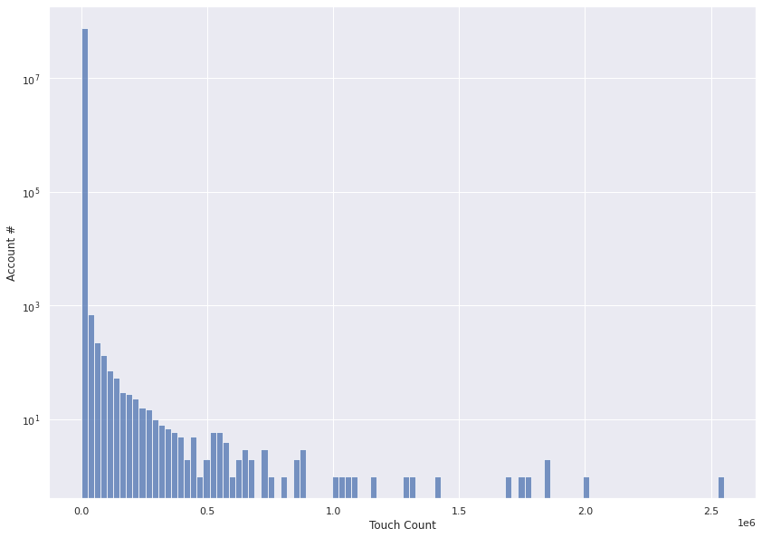

```python
fig, ax1 = mpl.subplots(1,1, figsize=(14,10))
ax1.set_xlabel('Touch Count')
ax1.set_yscale('log')
ax1.set_ylabel('Account #')
_ = sns.histplot(nacc, bins=100, ax=ax1, common_norm=False, common_bins=False)
```

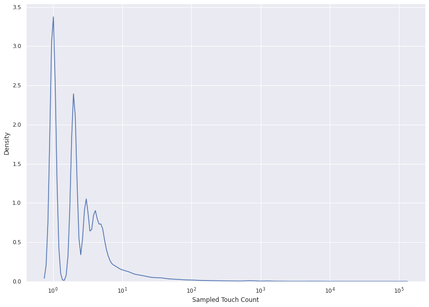

```python
# RANDOM Sample for KDE Plot
sample = numpy.random.choice(nacc, size=100000)

ax = sns.kdeplot(sample, log_scale=True, common_norm=False)
ax.set_xlabel('Sampled Touch Count')
```

From the histogram graph above, we can see that almost all (greater than 90%) of ethereum accounts are only touched (i.e. read/write) **less than 10 times**.

The number of account touches fall dramatically as the number of accounts increases indicating that there's a strong hub/spoke access pattern in the Ethereum ecosystem, where there's very few accounts that are accessed/used very frequently, while others are used very infrequently.

We also need to look at how sparsely they are accessed and on average what their lookup times are.

Renata suggested flipping the X and the Y. RL thought about it, but indeed the message that is being conveyed here is that there are very few accounts that get accessed more than 10 times.

```python
import os
RAW_DAT_DIR="/scratch/renlord/ethresearch-iterator"
if not os.path.isfile(f"{RAW_DAT_DIR}/blockheights-data"):
    print("Need to run ethresearch-iterator on muppet first!")
```

### Interblock Gap Metric

We check if state access pattern is correlated to interblock gap?

If state objects are frequently accessed in successive block heights? or the access pattern is more uniformly scattered across the entire blockchain?

```python
interblocks_list = []
with open(f"{RAW_DAT_DIR}/blockheights-inter-post150.dat", 'r') as f:
    for line in f:
        addr, interblocks = line.strip('\n').split(' ')
        interblocks = interblocks.split(',')
        interblocks_list += list(map(int, interblocks))

lo_interblocks = [ x for x in interblocks_list if x < 100000 ]
```

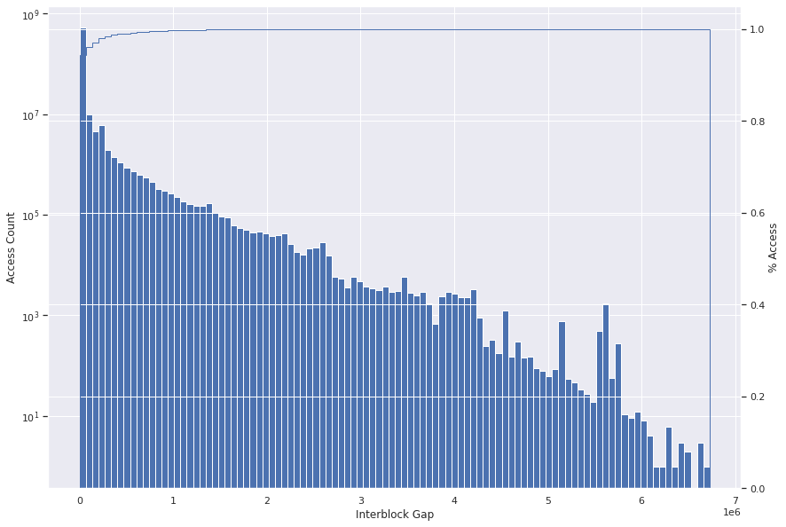

```python
fig, ax1 = mpl.subplots(1,1, figsize=(14,10))
ax1b = ax1.twinx()
ax1.set_xlabel('Interblock Gap')
ax1.set_ylabel('Access Count')
ax1.set_yscale('log')
ax1b.set_ylabel('% Access')
_ = ax1.hist(interblocks_list, bins=100, log=True)
_ = ax1b.hist(interblocks_list, bins=100, density=True, cumulative=True, histtype='step')
```

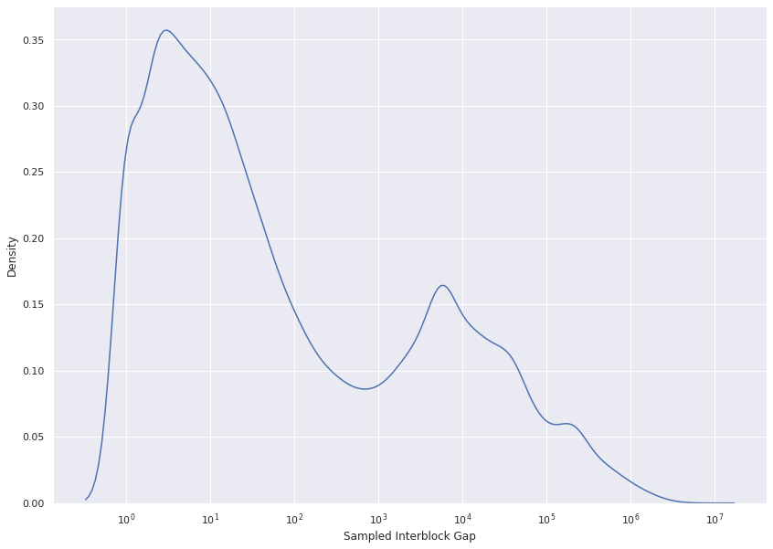

```python
# RANDOM Sample for KDE Plot
sample = numpy.random.choice(interblocks_list, size=100000)

ax = sns.kdeplot(sample, log_scale=True, common_norm=False)
ax.set_xlabel('Sampled Interblock Gap')
```

Despite poor spatial locality, it appears that Ethereum state access has good temporal locality, which suggest that LRU caching is a good caching policy.

This histogram plots interblock gaps against the number of state accesses (i.e. read or writes to a particular state object). We see that as the interblock gap rises between successive read/write, the number of access falls exponentially.

This suggest that high-use state objects are accessed frequently in succession. There is good reason to believe that caching high-use state objects will lead to improvement in IO access times.

## State Object Caching in `go-ethereum`

The geth implementation implement caching for state objects. When state objects are read, the client first tries to read from a runtime map object, multi-level caches and finally they are read from disk via leveldb. The read access hierarchy can be simplified in the diagram below:

| Access Hierarchy |
| --- |
| Runtime Map |
| TrieDB Clean Cache (GC-friendly) |
| TrieDB Dirty Cache (Go Map) |
| LevelDB Cache |
| LevelDB range lookup from Disc |

From top to bottom, access latency time increases.

The runtime map is a map data structure maintained by the go runtime. It is used exclusively to store state objects on first use when processing each block. After each block is processed, this map is deleted, garbage-collected and re-created by the Go runtime.

The TrieDB clean cache is a read-only cache that is GC-friendly such that its memory use and allocation is static through the entire runtime of the client independent of state size growth. The dirty cache is a read/write journal cache that is implemented using the Go map data structure. The difference between the two caches is that on each block, the dirty cache is flushed to disc, deleted, garbage-collected and re-created; while the clean cache continues to store previously read/fetched state objects from disc.

The leveldb cache is a cache implemented in the leveldb runtime, with its business logic separated from the client. It is also managed by the leveldb client. Finally, when reading state objects does not hit any caches, it is read from disc using leveldb lookups.

The data collected from profiling the clients consists of stack traces collected at snapshots taken at a frequency of 100hz over a 15s time interval where the 15s time interval span across the entire blockchain synchronisation process.

Using this data, we can infer if a `tryGet` function call in the sample was able to read the state object from disc or from one of the caches.

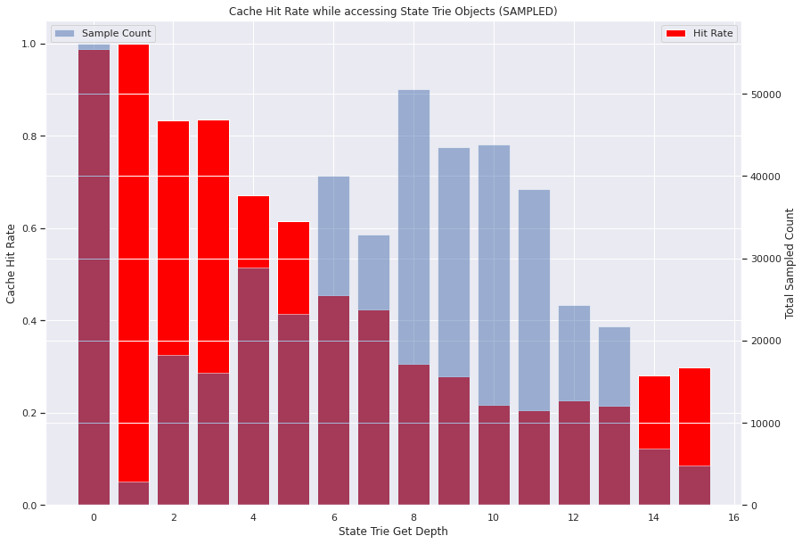

```python
# Cache Hit/Miss Rate for each tryGet count
datadir = '/scratch/renlord/CP3-RAW/before-23-06-geth/collapse/'
tryget_hit = [ 0 for i in range(21) ]
tryget_total = [ 0 for i in range(21) ]
for i in range(0, 1031):
    with open(f'{datadir}/{i}.collapse', 'r') as data:
        for line in data:
            if 'getState' in line or 'GetState' in line:
                layers = line.strip('\n').split(';')
                tryget_count = 0
                miss = False
                for layer in layers:
                    if 'tryGet' in layer:
                        tryget_count += 1
                    if 'leveldb' in layer:
                        miss = True
                if not miss:
                    tryget_hit[tryget_count] += 1
                tryget_total[tryget_count] += 1

fig = plt.figure()
ax = fig.add_subplot(111)
ax2 = ax.twinx()
ax.bar(list(range(0,16)), [ tryget_hit[i]/tryget_total[i] for i in range(16)], color='red', label='Hit Rate')
ax2.bar(list(range(0,16)), tryget_total[:16], alpha=0.5, label='Sample Count')
ax.set_xlabel('State Trie Get Depth')
ax.set_ylabel('Cache Hit Rate')
ax2.set_ylabel('Total Sampled Count')
ax.legend(loc=0)
ax2.legend(loc=2)
plt.title('Cache Hit Rate while accessing State Trie Objects (SAMPLED)')
plt.show()
```

### Analysis

Unsurprisingly, as the trie access depth increases, the cache hit rate decreases and most `getState` operation have high trie access depth that is greater than 7.

We treat the samples for depth greater than 15 as outliers because the collected sample count is very low.